# JayeshDabhi_PS3b_ANLY512_2016_IV

Jayesh_Dabhi

December 20, 2016

```r
library(readr)
library(dplyr)
data  <- read_csv("C:/Users/Jayesh/Desktop/DataBank/movie_data2.csv")
# Missing values 'NA" removal
data1 <- na.omit(data)


# Filtering data for movies rating >= 9.0
data2 <- filter(data, rating >= 7.0 & votes > 100000)
```

Vis_1 Number of movies released by different genre and year

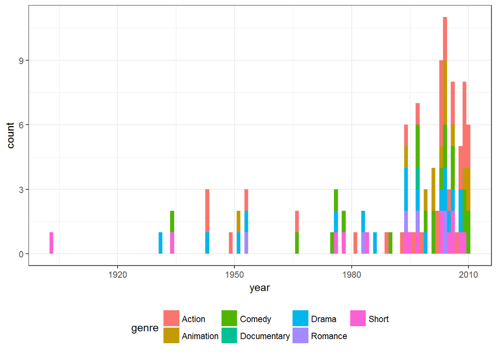

```r
library(ggplot2)
ggplot(data,aes(year, fill = genre))+geom_bar(width=1)+
  theme_bw()+theme(legend.position = "bottom")
```

Findings : By studying constructed graph “Number of Movies Vs. Year”, we can say that early years from 1900 - 1920 only very less numbers of short movies been produced. From 1920 to 1990 there was a little progress in film industry as movies of different genre been released like short, drama, comedy, actions and only one animation movie. The time span from 1990-2010 represents great progress in film industry as all genre of different movies been released.

# —————————————————————————————————-

Vis_2 Comparing movie earnings by genre and market area

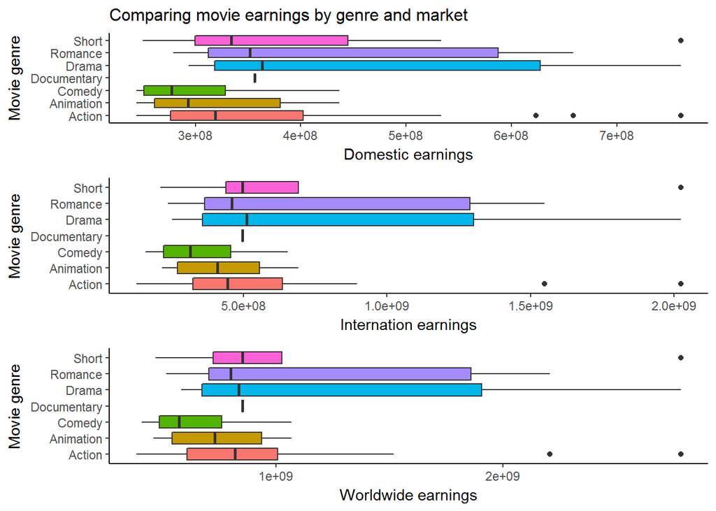

```r
library(ggplot2)
library(grid)
library(gridExtra)
p1 <- ggplot(data, aes(genre,domestic_earnings))+geom_boxplot(aes(fill=genre))+coord_flip()+
    labs(x="Movie genre", y= "Domestic earnings")+
    theme_classic()+guides(fill=FALSE)+
    ggtitle("Comparing movie earnings by genre and market")+
    theme(plot.title = element_text(size = 12))

p2 <- ggplot(data, aes(genre,international_earnings))+geom_boxplot(aes(fill=genre))+
  coord_flip()+
  labs(x="Movie genre", y="Internation earnings")+
  theme_classic()+guides(fill=FALSE)

p3 <- ggplot(data, aes(genre, worldwide_earnings))+geom_boxplot(aes(fill=genre))+
  coord_flip()+
  labs(x="Movie genre", y="Worldwide earnings")+
  theme_classic()+guides(fill=FALSE)

grid.arrange(p1, p2, p3, nrow=3)
```

# —————————————————————————————————————–

Vis_3

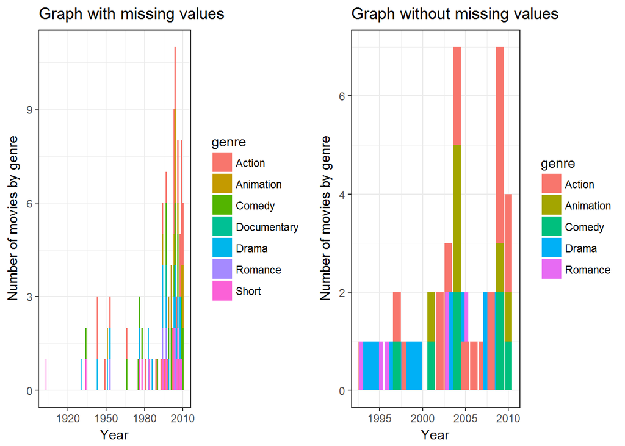

```r
# Now lets compare number of movies by genre after removing missing data points
par (mfrow = c(1,2))
p1 <- ggplot(data,aes(year, fill = genre))+geom_bar(width=1)+ theme_bw()+
        labs(x="Year", y="Number of movies by genre")+ggtitle("Graph with missing values")

p2 <- ggplot(data1,aes(year, fill = genre))+geom_bar()+  theme_bw()+
      labs(x="Year", y="Number of movies by genre")+ggtitle("Graph without missing values")

grid.arrange(p1, p2, ncol=2)
```

Findings : By studying constructed comparative graphs of “Number of Movies by genre Vs. Year” with and without missing values “NA”, it visually clear that until 1990 the data collected for movies having lots many missing information as “NA”. Therefore graph on right side without missing information doesn’t have any movies released before 1990. As mentioned in Vis_1, the duration from 1990 to 2010 shows great progress in film industry. From this comparative graphs, we can say that accurate data collection is very important for critical data analysis.

# —————————————————————————————————————–

Vis_2

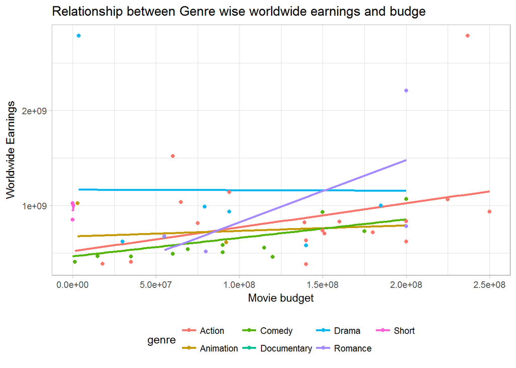

```r
library(ggthemes)
ggplot(data, aes(budget, worldwide_earnings, colour= genre))+
  geom_smooth(method = "lm", se= FALSE )+geom_point()+
  theme_bw()+
  labs(x="Movie budget", y="Worldwide Earnings")+
  ggtitle("Relationship between Genre wise worldwide earnings and budge")+
  theme_light()+
  theme(legend.position = "bottom")
```

# ————————————————————————————————————–